# CO2 analysis

This tutorial makes use of the following R package(s): **`tidyr`**, **`lubridate`** and **`ggplot2`**.

This material is intended to supplement **pages 159 to 169** of **Cleveland’s book**.

# An EDA example: CO2 analysis

Let’s start off by plotting the atmospheric CO2 concentrations (in ppm). The original dataset was pulled from [NOAA’s website](http://www.esrl.noaa.gov/gmd/ccgg/trends/).

```r
library(lubridate)
library(dplyr)
library(ggplot2)

d1 <- read.csv("http://mgimond.github.io/ES218/Data/CO2.csv")

d2 <- d1 %>%
      mutate( Date = ymd(paste(Year,"/", Month,"/15")),
              Year = as.numeric(decimal_date(Date)),
              CO2 = Interpolated)    %>%
     select(Year, Date, CO2)
```

Next, let’s look at the data:

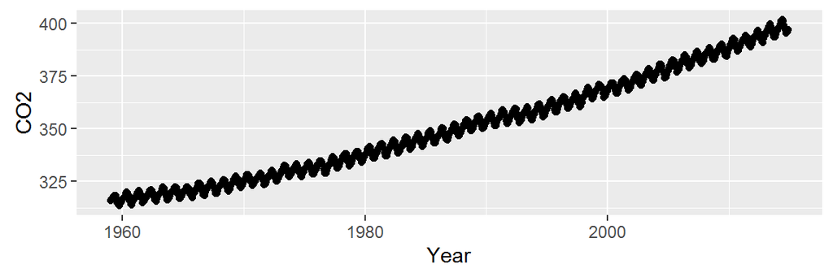

```r
ggplot(d2, aes(x=Year , y=CO2)) + geom_point()
```

Let’s see if plotting the data using lines instead of points helps identify any underlying pattern.

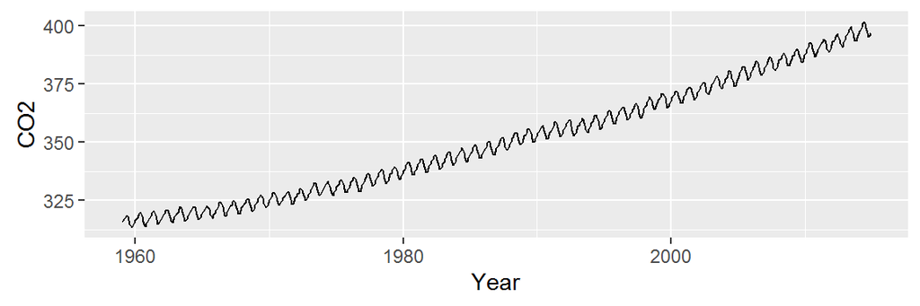

```r
ggplot(d2, aes(x=Year , y=CO2)) + geom_line()
```

We note two patterns of interest: an overall upward trend, and a cyclical trend. We will first *smooth* out the overall trend by finding a model that best explains the overall variability, then we’ll remove that trend from the data to explore the cyclical component.

# Exploring the overall trend

We can attempt to model the overall trend by fitting a straight line to the data using a standard regression analysis procedure. The fitted line is displayed in red in the following plot. We will use `ggplot2`’s built-in smoothing function to plot the regression line.

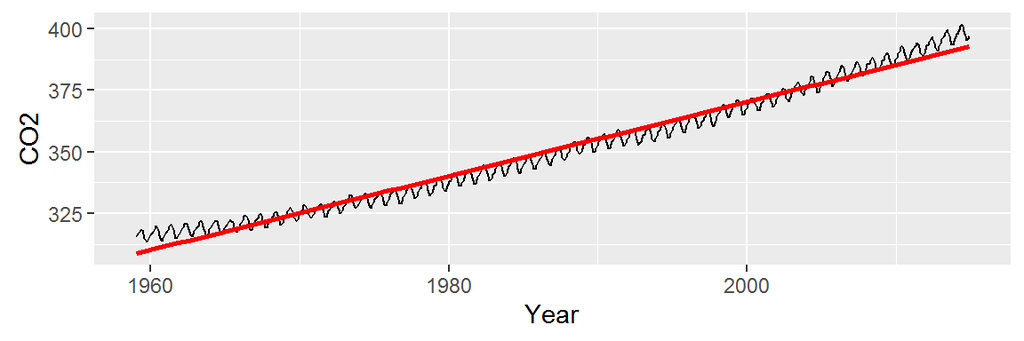

```r
ggplot(d2, aes(x=Year, y=CO2)) + geom_line() +
             stat_smooth(method="lm", se=FALSE, col="red")
```

Next, we subtract the modeled line from the CO2 data and plot the result–this gives us the **residuals** and can be thought of as representing what the linear model does *not* explain about the data. But first, we will need to create a regression model object since it will provide us with the residuals needed to generate the residual plot.

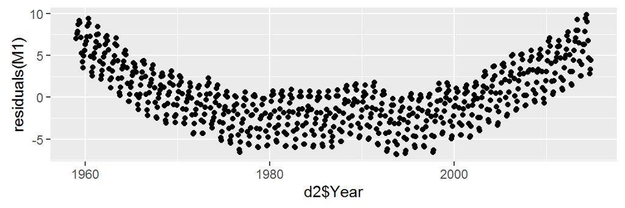

```r
# Generate a model object of the regression line
M1 <- lm(CO2 ~ Year, d2) # Generate model

# Plot the residuals from the model object
ggplot() + aes(x=d2$Year, y=residuals(M1)) + geom_point()
```

An overall trend is still present, despite having attempted to control for it. This implies that our simple line model does not do a good job in *smoothing* out the overall trend.

It appears that the overall trend is slightly convex and has a small peak around the 1990’s; we should try to fit the trend using a 3rd order polynomial of the form:

$$CO2_{trend} = a + b(Year) + c(Year^2) + d(Year^3)$$

The fitted line looks like this:

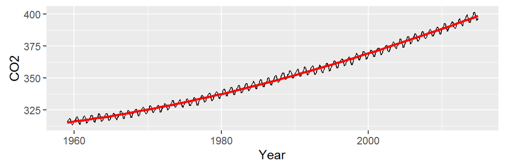

```r
# Third order polynomial
M2 <- lm(CO2 ~ Year * I(Year^2) * I(Year^3), d2)
ggplot(d2, aes(x=Year, y=CO2)) + geom_line() +
             stat_smooth(method="lm", formula=y ~ x + I(x^2) + I(x^3), se=FALSE, col="red")
```

Now, let’s look at the residuals. In helping discern any pattern in our residuals, we add a loess smooth to the plot.

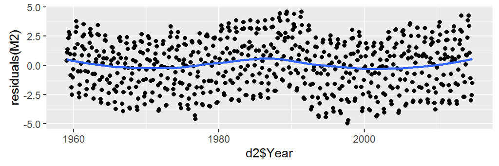

```r
ggplot() + aes(x=d2$Year, y=residuals(M2)) + geom_point() +
           stat_smooth(method="loess", se=FALSE)
```

This is an improvement over the simple line model (which was a 1st order polynomial fit). So what we have learned so far is that the overall trend is not perfectly linear but instead follows a parabolic like trajectory with a small hump halfway across the time span. However, we can still make out a “W” shaped trend in the residuals which can hamper our analysis of the oscillatory patterns in the data. We could play with different order polynomials to smooth the trend even further, but at this point, we may opt for a non-parametric fit. When the goal is to *peel* off one pattern to explore any underlying pattern we should not limit ourselves to parametric fits (which impose a mathematical model on our data) and instead explore non-parametric smoothing techniques that do not impose any structure on the data. An example of such a smoothing technique is the loess fit which is shown in the following figure.

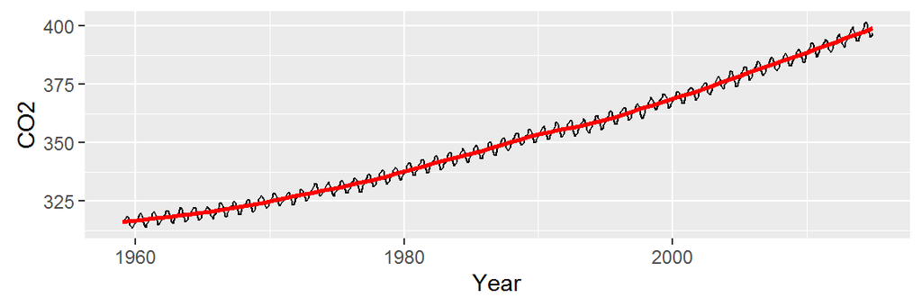

```r
lo <- loess(CO2 ~ Year, d2, span=1/4)
ggplot(d2, aes(x=Year, y=CO2)) + geom_line() +
             stat_smooth(span=1/4, se=FALSE, col="red")
```

At first glance, this may not look any different from our 3rd order polynomial. But the resulting residuals suggest that the loess smooth did a good job in removing any overall trend in our batch of CO2 values.

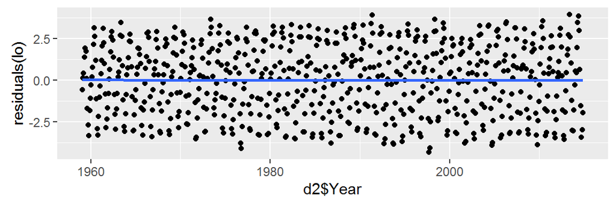

```r
ggplot() + aes(x=d2$Year, y=residuals(lo)) + geom_point() +
           stat_smooth(se=FALSE)
```

# Exploring the seasonal component

Now, we may be tempted to fit a *smooth* (as Tukey would say) to the residuals but that may not prove to be fruitful. Instead let’s see if the oscillation follows a 12 month cycle. We’ll group all the residual values by month of the year. In other words, we will remove the year *tag* associated with each value and explore those values as a function of month alone. Each month’s batch of values is distilled into a boxplot.

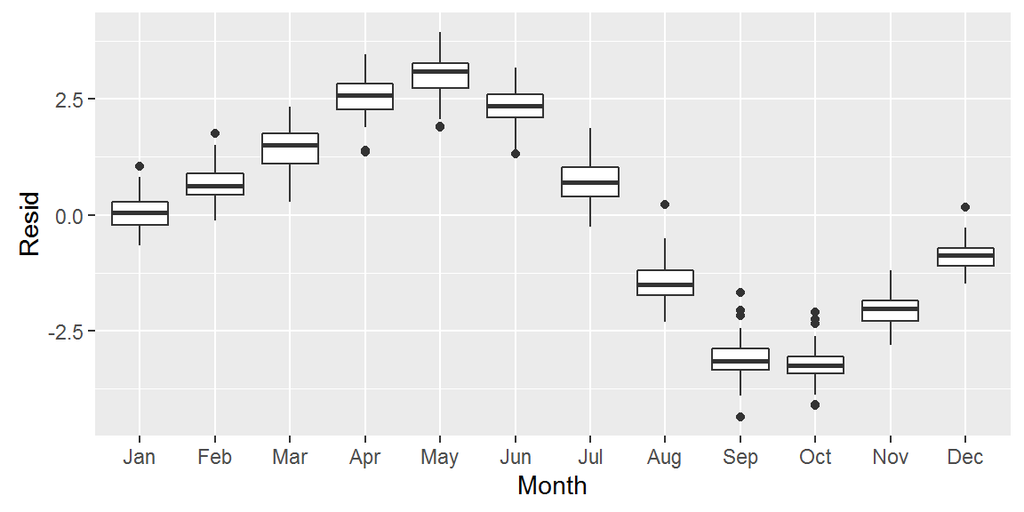

```r
# Aggregate residuals by year
d2$Month <- month(d2$Date, label=TRUE)
d2$Resid <- residuals(lo)
ggplot(d2, aes(x=Month, y=Resid)) + geom_boxplot()
```

It’s clear from the plot that the oscillation we observed in the CO2 plot follows a yearly cycle: a peak in the spring and a dip in the fall. This cycle is explained in part by the increased land mass in the northern hemisphere relative to the southern hemisphere. Because plants (and by extension photosynthesis) goes dormant during the winter months in the northern hemisphere, atmospheric CO2 is no longer being photosynthesized; this despite the southern hemisphere’s photosynthesis peak during the October-March period (a result of the southern hemisphere’s smaller land mass). Other factors such as increased CO2 emissions during the winter months may also contribute to the oscillatory nature of atmospheric CO2 concentrations.

Thus far, we have uncovered two patterns of interest: an overall trend and a cyclical component. Note that to effectively explore the cyclical pattern we had to **de-trend** (or **smooth**) the data. Next, we should *smooth* the seasonal component of the data to see if another pattern emerges. We may, for example, smooth the data by subtracting the monthly median from each residual leaving us with the next batch of residual values to explore:

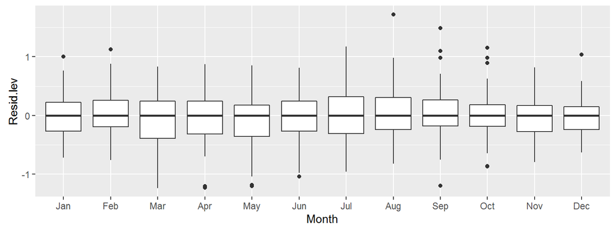

```r
d3 <- d2 %>%
  group_by(month(Date)) %>%
  mutate(Resid.lev = Resid - median(Resid))

ggplot(d3, aes(x=Month, y=Resid.lev)) + geom_boxplot()
```

Note that now, all the boxplots are lined up along their median values. We are now exploring the data after having accounted for both overall trend and seasonality. What can be gleaned from this dataset? We may want to explore the skewed nature of the residuals in March, or the narrower range of CO2 values for the fall months, for example.

We may also be interested in seeing if any trend in CO2 concentrations exists within each month. Let’s explore this by fitting a first order polynomial to the monthly data.

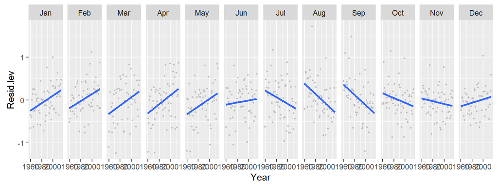

```r
ggplot(d3, aes(x=Year, y=Resid.lev)) + geom_point(col="grey", cex=.6)  +
     stat_smooth(se=FALSE, method="lm") + facet_grid(. ~ Month)
```

Note the overall increase in CO2 for the winter and spring months followed by a similar (but not as persistent) decrease in CO2 loss in the summer and fall months. This suggests an increase in cyclical amplitude with the deviation from a central value being possibly greater for the winter/spring months.

Let’s fit a loess to see if the trends within each month are monotonic.

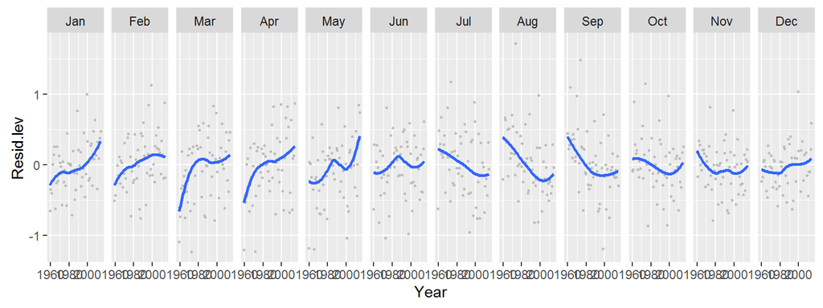

```r
ggplot(d3, aes(x=Year, y=Resid.lev)) + geom_point(col="grey", cex=.6)  +
     stat_smooth(method="loess", se=FALSE,
                 method.args=list(family="symmetric")) +
     facet_grid(. ~ Month)
```

The trends are clearly not monotonic suggesting that the processes driving the cyclical concentrations of CO2 are not systematic. However, despite the curved nature of the fits, the overall trends observed with the straight lines still remain.

# Exploring what remains

Now that we’ve fitted the monthly medians to the seasonal component of the data, let’s plot the residuals across the years.

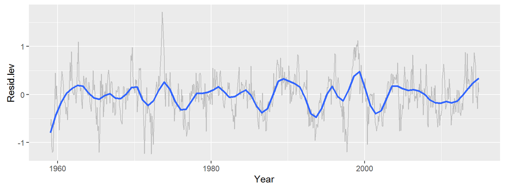

```r
ggplot(d3, aes(x=Year, y=Resid.lev)) +  geom_line(col="grey") +
     stat_smooth(method="loess", se=FALSE, span=0.1 ,
                 method.args=list(family="symmetric", degree=2))
```

Let’s overlay the SOI data on top of our last plot.

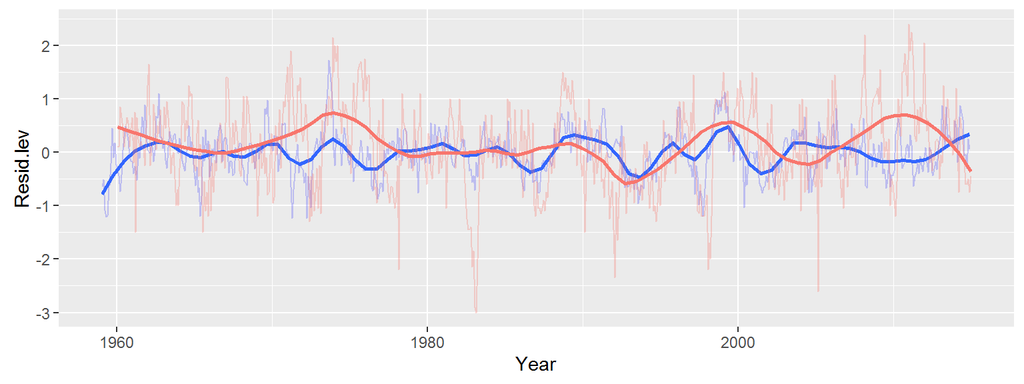

```r
library(tidyr)
library(lubridate)

soi <- read.csv("http://mgimond.github.io/ES218/Data/Southern_oscillation.csv")

soi <- gather(soi,key=Month, value=Index, -1)
Date <- ymd(paste(soi$YEAR, soi$Month, 15) )
soi$Yr <- decimal_date(Date)

ggplot(d3, aes(x=Year, y=Resid.lev)) +
             geom_line(col="blue", alpha=0.2) +
             stat_smooth(method="loess", se=FALSE, span=0.1,
                         method.args=list(family="symmetric", degree=2)) +
             geom_line(dat=soi, aes(Yr, Index/2, colour="red"), alpha=0.3) +
             stat_smooth(dat=soi, aes(Yr, Index/2, colour="red"),
                         method="loess", se=FALSE, span=0.2,
                         method.args=list(family="symmetric", degree=2)) +
             guides(color=FALSE)
```

It’s important to realize that this is one of many ways in which we could have proceeded with the analysis. For example, we could have started off the analysis by removing the seasonal component from the data, then analyzed the long term trend. This is the approach taken by William Cleveland on page 165 of the course’s text.

Manny Gimond (2016)